V3 · Website archive ↗

# NCAA Distance Running EDA

*Note: Most of the plots here were generated with the help of AI for quick reference. All this data is being used to inform a ML model about the impacts of different school on track and field performance.*

```python
import numpy as np
import pandas as pd
import seaborn as sns
import matplotlib.pyplot as plt
from matplotlib.ticker import FuncFormatter
from IPython.display import Markdown, display

sns.set_theme(style='whitegrid', context='talk')
plt.rcParams['figure.figsize'] = (12, 6)
```

## 1) Load Data and Data Cleaning

```python
df = pd.read_csv('tfrrs_all_distance_events_one_csv.csv').copy()

def time_to_seconds(value):
    if pd.isna(value):
        return np.nan
    s = str(value).strip().replace('@', '').replace('*', '')
    if not s:
        return np.nan
    parts = s.split(':')
    try:
        if len(parts) == 1:
            return float(parts[0])
        if len(parts) == 2:
            return int(parts[0]) * 60 + float(parts[1])
        if len(parts) == 3:
            return int(parts[0]) * 3600 + int(parts[1]) * 60 + float(parts[2])
    except ValueError:
        return np.nan
    return np.nan

def seconds_to_clock(x, pos=None):
    if pd.isna(x):
        return ''
    t = int(round(max(float(x), 0.0)))
    h, rem = divmod(t, 3600)
    m, s = divmod(rem, 60)
    if h > 0:
        return f'{h}:{m:02d}:{s:02d}'
    return f'{m}:{s:02d}'

df['Date_dt'] = pd.to_datetime(df['Date'], errors='coerce')
df['Year_num'] = pd.to_numeric(df['Year'], errors='coerce')
df['Month_num'] = df['Date_dt'].dt.month
df['Month_name'] = pd.Categorical(
    df['Date_dt'].dt.strftime('%b'),
    categories=['Jan','Feb','Mar','Apr','May','Jun','Jul','Aug','Sep','Oct','Nov','Dec'],
    ordered=True
)
df['Performance_Seconds'] = df['Performance Time'].apply(time_to_seconds)

# 2021 is often sparse/partial in this scrape history, so remove it for cleaner comparisons.
df = df[df['Year_num'] != 2021].copy()

print(f'Rows: {len(df):,}')
print(f'Columns: {df.shape[1]}')
print(f'Events: {df["Event"].nunique()} | Schools: {df["Athlete School"].nunique()} | Athletes: {df["Athlete Name"].nunique()}')
print(f'Non-null performance seconds: {df["Performance_Seconds"].notna().sum():,}')
```

```
Rows: 75,732
Columns: 15
Events: 5 | Schools: 380 | Athletes: 15665
Non-null performance seconds: 70,355
```

```python
quality = pd.DataFrame({
    'column': df.columns,
    'dtype': [str(x) for x in df.dtypes],
    'nulls': [int(df[c].isna().sum()) for c in df.columns],
    'null_pct': [round(df[c].isna().mean() * 100, 2) for c in df.columns],
    'n_unique': [int(df[c].nunique(dropna=True)) for c in df.columns]
}).sort_values('null_pct', ascending=False)

display(quality.head(15))
display(df.head(5))
```

|  | column | dtype | nulls | null_pct | n_unique |
| --- | --- | --- | --- | --- | --- |
| 14 | Performance_Seconds | float64 | 5377 | 7.10 | 41132 |
| 8 | Athlete Year | object | 27 | 0.04 | 8 |
| 0 | Season | object | 0 | 0.00 | 2 |
| 1 | Date | object | 0 | 0.00 | 336 |
| 2 | Year | int64 | 0 | 0.00 | 4 |
| 3 | Month | object | 0 | 0.00 | 7 |
| 4 | Event | object | 0 | 0.00 | 5 |
| 5 | Gender | object | 0 | 0.00 | 2 |
| 6 | Athlete Name | object | 0 | 0.00 | 15665 |
| 7 | Athlete School | object | 0 | 0.00 | 380 |
| 9 | Performance Time | object | 0 | 0.00 | 48289 |
| 10 | Date_dt | datetime64[ns] | 0 | 0.00 | 336 |
| 11 | Year_num | int64 | 0 | 0.00 | 4 |
| 12 | Month_num | int32 | 0 | 0.00 | 7 |
| 13 | Month_name | category | 0 | 0.00 | 7 |

|  | Season | Date | Year | Month | Event | Gender | Athlete Name | Athlete School | Athlete Year | Performance Time | Date_dt | Year_num | Month_num | Month_name | Performance_Seconds |
| --- | --- | --- | --- | --- | --- | --- | --- | --- | --- | --- | --- | --- | --- | --- | --- |
| 0 | indoor | Feb 11, 2022 | 2022 | February | mile | Male | Beadlescomb, Morgan | Michigan State | SR-4 | 3:52.03 | 2022-02-11 | 2022 | 2 | Feb | 232.03 |
| 1 | indoor | Feb 11, 2022 | 2022 | February | mile | Male | Garcia Romo, Mario | Ole Miss | JR-3 | 3:53.36 | 2022-02-11 | 2022 | 2 | Feb | 233.36 |
| 2 | indoor | Jan 21, 2022 | 2022 | January | mile | Male | Young, Nico | Northern Arizona | FR-1 | 3:54.07 @ | 2022-01-21 | 2022 | 1 | Jan | 234.07 |
| 3 | indoor | Feb 11, 2022 | 2022 | February | mile | Male | Kipsang, Eliud | Alabama | FR-1 | 3:54.36 | 2022-02-11 | 2022 | 2 | Feb | 234.36 |
| 4 | indoor | Jan 22, 2022 | 2022 | January | mile | Male | Nuguse, Yared | Notre Dame | SR-4 | 3:54.46 | 2022-01-22 | 2022 | 1 | Jan | 234.46 |

## 2) Participation

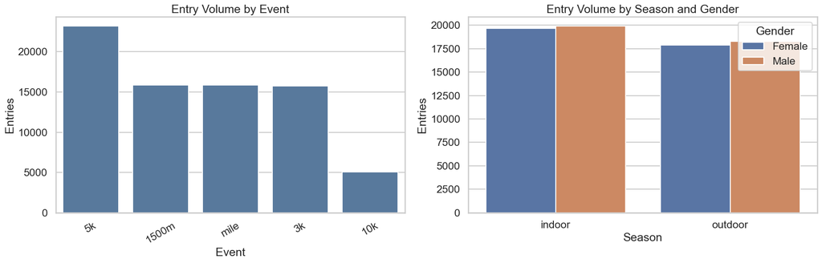

```python
fig, axes = plt.subplots(1, 2, figsize=(18, 6))

event_counts = df['Event'].value_counts().reset_index()
event_counts.columns = ['Event', 'Entries']
sns.barplot(data=event_counts, x='Event', y='Entries', ax=axes[0], color='#4C78A8')
axes[0].set_title('Entry Volume by Event')
axes[0].tick_params(axis='x', rotation=30)

season_counts = df.groupby(['Season', 'Gender'], as_index=False).size().rename(columns={'size': 'Entries'})
sns.barplot(data=season_counts, x='Season', y='Entries', hue='Gender', order=['indoor', 'outdoor'], ax=axes[1])
axes[1].set_title('Entry Volume by Season and Gender')

plt.tight_layout()
plt.show()
```

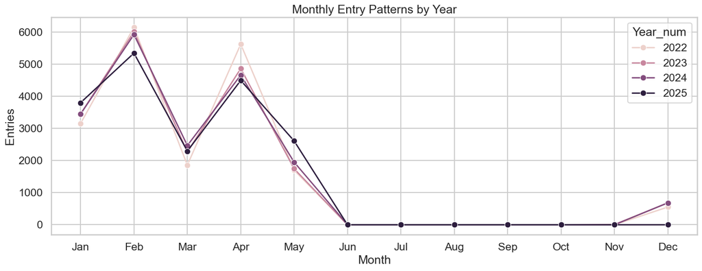

```python
monthly = (
    df.dropna(subset=['Date_dt'])
      .groupby(['Year_num', 'Month_name'], as_index=False)
      .size()
      .rename(columns={'size': 'Entries'})
)

plt.figure(figsize=(15, 6))
sns.lineplot(data=monthly, x='Month_name', y='Entries', hue='Year_num', marker='o', linewidth=2)
plt.title('Monthly Entry Patterns by Year')
plt.xlabel('Month')
plt.ylabel('Entries')
plt.tight_layout()
plt.show()
```

### Analysis

- This makes sense. The indoor season peaks in Feb with conference in March, so there will be less entries.
- Outdoor season peaks in Apr with conference in May. There are some meets in December.

## 3) Performance Distributions

How do times differ by event, season, and gender?

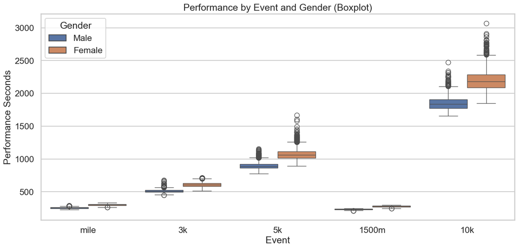

```python
perf = df.dropna(subset=['Performance_Seconds']).copy()

plt.figure(figsize=(16, 7))
sns.boxplot(data=perf, x='Event', y='Performance_Seconds', hue='Gender')
plt.title('Performance by Event and Gender (Boxplot)')
plt.ylabel('Performance Seconds')

plt.show()
```